# Risk Factor Analysis

## Outcome Variable

**Outcome Variable:** ever_wasted

## Predictor Variables

**Intervention Variable:** mhtcm

**Adjustment Set:**

unadjusted

## Stratifying Variables

The analysis was stratified on these variable(s):

- agecat
- studyid
- country

## Data Summary

| agecat | studyid | country | mhtcm | ever_wasted | n_cell | n |
| --- | --- | --- | --- | --- | --- | --- |
| 0-24 months | COHORTS | GUATEMALA | >=155 cm | 0 | 121 | 1275 |
| 0-24 months | COHORTS | GUATEMALA | >=155 cm | 1 | 44 | 1275 |
| 0-24 months | COHORTS | GUATEMALA | <151 cm | 0 | 605 | 1275 |
| 0-24 months | COHORTS | GUATEMALA | <151 cm | 1 | 230 | 1275 |
| 0-24 months | COHORTS | GUATEMALA | [151-155) cm | 0 | 214 | 1275 |
| 0-24 months | COHORTS | GUATEMALA | [151-155) cm | 1 | 61 | 1275 |
| 0-24 months | COHORTS | INDIA | >=155 cm | 0 | 381 | 1905 |
| 0-24 months | COHORTS | INDIA | >=155 cm | 1 | 190 | 1905 |
| 0-24 months | COHORTS | INDIA | <151 cm | 0 | 547 | 1905 |
| 0-24 months | COHORTS | INDIA | <151 cm | 1 | 276 | 1905 |
| 0-24 months | COHORTS | INDIA | [151-155) cm | 0 | 341 | 1905 |
| 0-24 months | COHORTS | INDIA | [151-155) cm | 1 | 170 | 1905 |
| 0-24 months | COHORTS | PHILIPPINES | >=155 cm | 0 | 389 | 3045 |
| 0-24 months | COHORTS | PHILIPPINES | >=155 cm | 1 | 240 | 3045 |
| 0-24 months | COHORTS | PHILIPPINES | <151 cm | 0 | 878 | 3045 |
| 0-24 months | COHORTS | PHILIPPINES | <151 cm | 1 | 662 | 3045 |
| 0-24 months | COHORTS | PHILIPPINES | [151-155) cm | 0 | 549 | 3045 |
| 0-24 months | COHORTS | PHILIPPINES | [151-155) cm | 1 | 327 | 3045 |
| 0-24 months | Guatemala BSC | GUATEMALA | >=155 cm | 0 | 33 | 235 |
| 0-24 months | Guatemala BSC | GUATEMALA | >=155 cm | 1 | 3 | 235 |
| 0-24 months | Guatemala BSC | GUATEMALA | <151 cm | 0 | 127 | 235 |
| 0-24 months | Guatemala BSC | GUATEMALA | <151 cm | 1 | 16 | 235 |
| 0-24 months | Guatemala BSC | GUATEMALA | [151-155) cm | 0 | 49 | 235 |
| 0-24 months | Guatemala BSC | GUATEMALA | [151-155) cm | 1 | 7 | 235 |
| 0-24 months | iLiNS-Zinc | BURKINA FASO | >=155 cm | 0 | 2261 | 3217 |
| 0-24 months | iLiNS-Zinc | BURKINA FASO | >=155 cm | 1 | 639 | 3217 |
| 0-24 months | iLiNS-Zinc | BURKINA FASO | <151 cm | 0 | 62 | 3217 |
| 0-24 months | iLiNS-Zinc | BURKINA FASO | <151 cm | 1 | 29 | 3217 |
| 0-24 months | iLiNS-Zinc | BURKINA FASO | [151-155) cm | 0 | 161 | 3217 |
| 0-24 months | iLiNS-Zinc | BURKINA FASO | [151-155) cm | 1 | 65 | 3217 |

[output cut: 378 more lines]

The following strata were considered:

- agecat: 0-24 months, studyid: COHORTS, country: GUATEMALA
- agecat: 0-24 months, studyid: COHORTS, country: INDIA
- agecat: 0-24 months, studyid: COHORTS, country: PHILIPPINES
- agecat: 0-24 months, studyid: Guatemala BSC, country: GUATEMALA
- agecat: 0-24 months, studyid: iLiNS-Zinc, country: BURKINA FASO
- agecat: 0-24 months, studyid: JiVitA-3, country: BANGLADESH
- agecat: 0-24 months, studyid: Keneba, country: GAMBIA
- agecat: 0-24 months, studyid: LCNI-5, country: MALAWI
- agecat: 0-24 months, studyid: MAL-ED, country: BANGLADESH
- agecat: 0-24 months, studyid: MAL-ED, country: BRAZIL
- agecat: 0-24 months, studyid: MAL-ED, country: INDIA
- agecat: 0-24 months, studyid: MAL-ED, country: NEPAL
- agecat: 0-24 months, studyid: MAL-ED, country: PERU
- agecat: 0-24 months, studyid: MAL-ED, country: SOUTH AFRICA
- agecat: 0-24 months, studyid: MAL-ED, country: TANZANIA, UNITED REPUBLIC OF
- agecat: 0-24 months, studyid: NIH-Birth, country: BANGLADESH
- agecat: 0-24 months, studyid: NIH-Crypto, country: BANGLADESH
- agecat: 0-24 months, studyid: PROBIT, country: BELARUS
- agecat: 0-24 months, studyid: PROVIDE, country: BANGLADESH
- agecat: 0-24 months, studyid: SAS-CompFeed, country: INDIA
- agecat: 0-24 months, studyid: SAS-FoodSuppl, country: INDIA
- agecat: 0-24 months, studyid: TanzaniaChild2, country: TANZANIA, UNITED REPUBLIC OF
- agecat: 0-24 months, studyid: ZVITAMBO, country: ZIMBABWE
- agecat: 0-6 months, studyid: COHORTS, country: GUATEMALA
- agecat: 0-6 months, studyid: COHORTS, country: INDIA
- agecat: 0-6 months, studyid: COHORTS, country: PHILIPPINES
- agecat: 0-6 months, studyid: Guatemala BSC, country: GUATEMALA
- agecat: 0-6 months, studyid: JiVitA-3, country: BANGLADESH
- agecat: 0-6 months, studyid: Keneba, country: GAMBIA
- agecat: 0-6 months, studyid: LCNI-5, country: MALAWI
- agecat: 0-6 months, studyid: MAL-ED, country: BANGLADESH
- agecat: 0-6 months, studyid: MAL-ED, country: BRAZIL
- agecat: 0-6 months, studyid: MAL-ED, country: INDIA
- agecat: 0-6 months, studyid: MAL-ED, country: NEPAL
- agecat: 0-6 months, studyid: MAL-ED, country: PERU
- agecat: 0-6 months, studyid: MAL-ED, country: SOUTH AFRICA
- agecat: 0-6 months, studyid: MAL-ED, country: TANZANIA, UNITED REPUBLIC OF
- agecat: 0-6 months, studyid: NIH-Birth, country: BANGLADESH
- agecat: 0-6 months, studyid: NIH-Crypto, country: BANGLADESH
- agecat: 0-6 months, studyid: PROBIT, country: BELARUS
- agecat: 0-6 months, studyid: PROVIDE, country: BANGLADESH
- agecat: 0-6 months, studyid: SAS-CompFeed, country: INDIA
- agecat: 0-6 months, studyid: SAS-FoodSuppl, country: INDIA
- agecat: 0-6 months, studyid: TanzaniaChild2, country: TANZANIA, UNITED REPUBLIC OF
- agecat: 0-6 months, studyid: ZVITAMBO, country: ZIMBABWE
- agecat: 6-24 months, studyid: COHORTS, country: GUATEMALA
- agecat: 6-24 months, studyid: COHORTS, country: INDIA
- agecat: 6-24 months, studyid: COHORTS, country: PHILIPPINES
- agecat: 6-24 months, studyid: Guatemala BSC, country: GUATEMALA
- agecat: 6-24 months, studyid: iLiNS-Zinc, country: BURKINA FASO
- agecat: 6-24 months, studyid: JiVitA-3, country: BANGLADESH
- agecat: 6-24 months, studyid: Keneba, country: GAMBIA
- agecat: 6-24 months, studyid: LCNI-5, country: MALAWI
- agecat: 6-24 months, studyid: MAL-ED, country: BANGLADESH
- agecat: 6-24 months, studyid: MAL-ED, country: BRAZIL
- agecat: 6-24 months, studyid: MAL-ED, country: INDIA
- agecat: 6-24 months, studyid: MAL-ED, country: NEPAL
- agecat: 6-24 months, studyid: MAL-ED, country: PERU
- agecat: 6-24 months, studyid: MAL-ED, country: SOUTH AFRICA
- agecat: 6-24 months, studyid: MAL-ED, country: TANZANIA, UNITED REPUBLIC OF
- agecat: 6-24 months, studyid: NIH-Birth, country: BANGLADESH
- agecat: 6-24 months, studyid: NIH-Crypto, country: BANGLADESH
- agecat: 6-24 months, studyid: PROBIT, country: BELARUS
- agecat: 6-24 months, studyid: PROVIDE, country: BANGLADESH
- agecat: 6-24 months, studyid: SAS-CompFeed, country: INDIA
- agecat: 6-24 months, studyid: SAS-FoodSuppl, country: INDIA
- agecat: 6-24 months, studyid: TanzaniaChild2, country: TANZANIA, UNITED REPUBLIC OF
- agecat: 6-24 months, studyid: ZVITAMBO, country: ZIMBABWE

### Dropped Strata

Some strata were dropped due to rare outcomes:

- agecat: 0-24 months, studyid: Guatemala BSC, country: GUATEMALA
- agecat: 0-24 months, studyid: MAL-ED, country: BRAZIL
- agecat: 0-24 months, studyid: MAL-ED, country: PERU
- agecat: 0-24 months, studyid: MAL-ED, country: SOUTH AFRICA
- agecat: 0-6 months, studyid: Guatemala BSC, country: GUATEMALA
- agecat: 0-6 months, studyid: LCNI-5, country: MALAWI
- agecat: 0-6 months, studyid: MAL-ED, country: BRAZIL
- agecat: 0-6 months, studyid: MAL-ED, country: PERU
- agecat: 0-6 months, studyid: MAL-ED, country: SOUTH AFRICA
- agecat: 0-6 months, studyid: MAL-ED, country: TANZANIA, UNITED REPUBLIC OF
- agecat: 6-24 months, studyid: Guatemala BSC, country: GUATEMALA
- agecat: 6-24 months, studyid: MAL-ED, country: BANGLADESH
- agecat: 6-24 months, studyid: MAL-ED, country: BRAZIL
- agecat: 6-24 months, studyid: MAL-ED, country: PERU
- agecat: 6-24 months, studyid: MAL-ED, country: SOUTH AFRICA
- agecat: 6-24 months, studyid: PROBIT, country: BELARUS

## Methods Detail

We’re interested in the causal parameters $E[Y_a]$ for all values of $a \in \mathcal{A}$. These parameters represent the mean outcome if, possibly contrary to fact, we intervened to set all units to have $A=a$. Under the randomization and positivity assumptions, these are identified by the statistical parameters $\psi_a=E_W[E_{Y|A,W}(Y|A=a,W)]$. In addition, we’re interested in the mean of $Y$, $E[Y]$ under no intervention (the observed mean). We will estimate these parameters by using SuperLearner to fit the relevant likelihood factors – $E_{Y|A,W}(Y|A=a,W)$ and $p(A=a|W)$, and then updating our likelihood fit using a joint TMLE.

For unadjusted analyses ($W=\{\}$), initial likelihoods were estimated using Lrnr_glm to estimate the simple $E(Y|A)$ and Lrnr_mean to estimate $p(A)$. For adjusted analyses, a small library containing Lrnr_glmnet, Lrnr_xgboost, and Lrnr_mean was used.

Having estimated these parameters, we will then use the delta method to estimate relative risks and attributable risks relative to a prespecified baseline level of $A$.

# Results Detail

## Results Plots

[figure not shown]

[figure not shown]

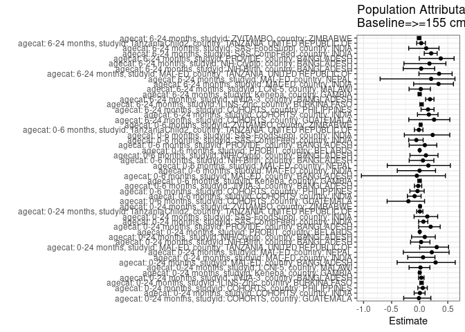

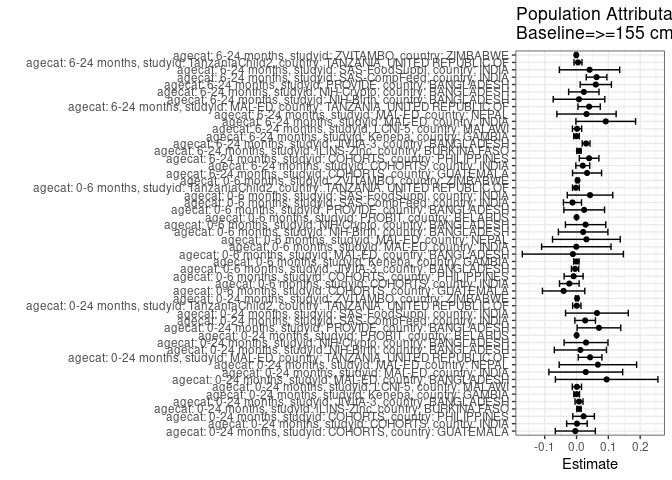

## Results Table

### Parameter: TSM

| agecat | studyid | country | intervention_level | baseline_level | estimate | ci_lower | ci_upper |
| --- | --- | --- | --- | --- | --- | --- | --- |
| 0-24 months | COHORTS | GUATEMALA | >=155 cm | NA | 0.2666667 | 0.1991655 | 0.3341679 |
| 0-24 months | COHORTS | GUATEMALA | <151 cm | NA | 0.2754491 | 0.2451360 | 0.3057622 |
| 0-24 months | COHORTS | GUATEMALA | [151-155) cm | NA | 0.2218182 | 0.1726945 | 0.2709419 |
| 0-24 months | COHORTS | INDIA | >=155 cm | NA | 0.3327496 | 0.2940909 | 0.3714083 |
| 0-24 months | COHORTS | INDIA | <151 cm | NA | 0.3353584 | 0.3030950 | 0.3676219 |
| 0-24 months | COHORTS | INDIA | [151-155) cm | NA | 0.3326810 | 0.2918178 | 0.3735442 |
| 0-24 months | COHORTS | PHILIPPINES | >=155 cm | NA | 0.3815580 | 0.3435895 | 0.4195266 |
| 0-24 months | COHORTS | PHILIPPINES | <151 cm | NA | 0.4298701 | 0.4051407 | 0.4545996 |
| 0-24 months | COHORTS | PHILIPPINES | [151-155) cm | NA | 0.3732877 | 0.3412528 | 0.4053226 |
| 0-24 months | iLiNS-Zinc | BURKINA FASO | >=155 cm | NA | 0.2203448 | 0.1913531 | 0.2493366 |
| 0-24 months | iLiNS-Zinc | BURKINA FASO | <151 cm | NA | 0.3186813 | 0.1888746 | 0.4484881 |
| 0-24 months | iLiNS-Zinc | BURKINA FASO | [151-155) cm | NA | 0.2876106 | 0.2255886 | 0.3496327 |
| 0-24 months | JiVitA-3 | BANGLADESH | >=155 cm | NA | 0.2503635 | 0.2358328 | 0.2648943 |
| 0-24 months | JiVitA-3 | BANGLADESH | <151 cm | NA | 0.2611837 | 0.2533483 | 0.2690191 |
| 0-24 months | JiVitA-3 | BANGLADESH | [151-155) cm | NA | 0.2553348 | 0.2437664 | 0.2669032 |
| 0-24 months | Keneba | GAMBIA | >=155 cm | NA | 0.4660050 | 0.4442197 | 0.4877903 |
| 0-24 months | Keneba | GAMBIA | <151 cm | NA | 0.4623656 | 0.3610136 | 0.5637175 |
| 0-24 months | Keneba | GAMBIA | [151-155) cm | NA | 0.4693252 | 0.4151401 | 0.5235102 |
| 0-24 months | LCNI-5 | MALAWI | >=155 cm | NA | 0.0778210 | 0.0546480 | 0.1009940 |
| 0-24 months | LCNI-5 | MALAWI | <151 cm | NA | 0.0610687 | 0.0200390 | 0.1020984 |
| 0-24 months | LCNI-5 | MALAWI | [151-155) cm | NA | 0.0937500 | 0.0524959 | 0.1350041 |
| 0-24 months | MAL-ED | BANGLADESH | >=155 cm | NA | 0.2400000 | 0.0722560 | 0.4077440 |
| 0-24 months | MAL-ED | BANGLADESH | <151 cm | NA | 0.3619632 | 0.2880425 | 0.4358839 |
| 0-24 months | MAL-ED | BANGLADESH | [151-155) cm | NA | 0.3030303 | 0.1919383 | 0.4141223 |
| 0-24 months | MAL-ED | INDIA | >=155 cm | NA | 0.4545455 | 0.3226791 | 0.5864118 |
| 0-24 months | MAL-ED | INDIA | <151 cm | NA | 0.5130435 | 0.4215015 | 0.6045855 |
| 0-24 months | MAL-ED | INDIA | [151-155) cm | NA | 0.4583333 | 0.3430045 | 0.5736621 |
| 0-24 months | MAL-ED | NEPAL | >=155 cm | NA | 0.2439024 | 0.1121777 | 0.3756272 |
| 0-24 months | MAL-ED | NEPAL | <151 cm | NA | 0.3383459 | 0.2577649 | 0.4189268 |
| 0-24 months | MAL-ED | NEPAL | [151-155) cm | NA | 0.2968750 | 0.1847053 | 0.4090447 |

[output cut: 126 more lines]

### Parameter: E(Y)

| agecat | studyid | country | intervention_level | baseline_level | estimate | ci_lower | ci_upper |
| --- | --- | --- | --- | --- | --- | --- | --- |
| 0-24 months | COHORTS | GUATEMALA | NA | NA | 0.2627451 | 0.2385772 | 0.2869130 |
| 0-24 months | COHORTS | INDIA | NA | NA | 0.3338583 | 0.3126757 | 0.3550409 |
| 0-24 months | COHORTS | PHILIPPINES | NA | NA | 0.4036125 | 0.3861835 | 0.4210415 |
| 0-24 months | iLiNS-Zinc | BURKINA FASO | NA | NA | 0.2278520 | 0.2008644 | 0.2548397 |
| 0-24 months | JiVitA-3 | BANGLADESH | NA | NA | 0.2580393 | 0.2515701 | 0.2645084 |
| 0-24 months | Keneba | GAMBIA | NA | NA | 0.4663106 | 0.4464881 | 0.4861331 |
| 0-24 months | LCNI-5 | MALAWI | NA | NA | 0.0788530 | 0.0605839 | 0.0971222 |
| 0-24 months | MAL-ED | BANGLADESH | NA | NA | 0.3346457 | 0.2765014 | 0.3927899 |
| 0-24 months | MAL-ED | INDIA | NA | NA | 0.4834711 | 0.4203794 | 0.5465628 |
| 0-24 months | MAL-ED | NEPAL | NA | NA | 0.3109244 | 0.2519946 | 0.3698541 |
| 0-24 months | MAL-ED | TANZANIA, UNITED REPUBLIC OF | NA | NA | 0.1406250 | 0.0979572 | 0.1832928 |
| 0-24 months | NIH-Birth | BANGLADESH | NA | NA | 0.4775641 | 0.4383415 | 0.5167867 |
| 0-24 months | NIH-Crypto | BANGLADESH | NA | NA | 0.3298013 | 0.2962438 | 0.3633589 |
| 0-24 months | PROBIT | BELARUS | NA | NA | 0.2807631 | 0.2185905 | 0.3429356 |
| 0-24 months | PROVIDE | BANGLADESH | NA | NA | 0.3602392 | 0.3238339 | 0.3966444 |
| 0-24 months | SAS-CompFeed | INDIA | NA | NA | 0.4107914 | 0.3512139 | 0.4703688 |
| 0-24 months | SAS-FoodSuppl | INDIA | NA | NA | 0.4743276 | 0.4258753 | 0.5227800 |
| 0-24 months | TanzaniaChild2 | TANZANIA, UNITED REPUBLIC OF | NA | NA | 0.2369648 | 0.2198019 | 0.2541277 |
| 0-24 months | ZVITAMBO | ZIMBABWE | NA | NA | 0.2467955 | 0.2382720 | 0.2553190 |
| 0-6 months | COHORTS | GUATEMALA | NA | NA | 0.2019139 | 0.1775635 | 0.2262643 |
| 0-6 months | COHORTS | INDIA | NA | NA | 0.2528180 | 0.2330767 | 0.2725593 |
| 0-6 months | COHORTS | PHILIPPINES | NA | NA | 0.2355453 | 0.2204685 | 0.2506222 |
| 0-6 months | JiVitA-3 | BANGLADESH | NA | NA | 0.1762154 | 0.1705946 | 0.1818362 |
| 0-6 months | Keneba | GAMBIA | NA | NA | 0.2843909 | 0.2653574 | 0.3034244 |
| 0-6 months | MAL-ED | BANGLADESH | NA | NA | 0.2283465 | 0.1766220 | 0.2800709 |
| 0-6 months | MAL-ED | INDIA | NA | NA | 0.3264463 | 0.2672449 | 0.3856476 |
| 0-6 months | MAL-ED | NEPAL | NA | NA | 0.2016807 | 0.1505956 | 0.2527658 |
| 0-6 months | NIH-Birth | BANGLADESH | NA | NA | 0.3569132 | 0.3192325 | 0.3945938 |
| 0-6 months | NIH-Crypto | BANGLADESH | NA | NA | 0.2569536 | 0.2257649 | 0.2881424 |
| 0-6 months | PROBIT | BELARUS | NA | NA | 0.2750109 | 0.2125981 | 0.3374238 |
| 0-6 months | PROVIDE | BANGLADESH | NA | NA | 0.2630792 | 0.2296894 | 0.2964690 |
| 0-6 months | SAS-CompFeed | INDIA | NA | NA | 0.2154736 | 0.1691818 | 0.2617655 |
| 0-6 months | SAS-FoodSuppl | INDIA | NA | NA | 0.1833741 | 0.1458251 | 0.2209231 |
| 0-6 months | TanzaniaChild2 | TANZANIA, UNITED REPUBLIC OF | NA | NA | 0.1394659 | 0.1254831 | 0.1534487 |
| 0-6 months | ZVITAMBO | ZIMBABWE | NA | NA | 0.1822917 | 0.1746442 | 0.1899391 |
| 6-24 months | COHORTS | GUATEMALA | NA | NA | 0.1288927 | 0.1095683 | 0.1482172 |
| 6-24 months | COHORTS | INDIA | NA | NA | 0.1199132 | 0.1050778 | 0.1347486 |
| 6-24 months | COHORTS | PHILIPPINES | NA | NA | 0.2666429 | 0.2502871 | 0.2829988 |
| 6-24 months | iLiNS-Zinc | BURKINA FASO | NA | NA | 0.2278520 | 0.2008644 | 0.2548397 |
| 6-24 months | JiVitA-3 | BANGLADESH | NA | NA | 0.1637386 | 0.1576238 | 0.1698535 |
| 6-24 months | Keneba | GAMBIA | NA | NA | 0.3284609 | 0.3093705 | 0.3475512 |
| 6-24 months | LCNI-5 | MALAWI | NA | NA | 0.0765492 | 0.0583736 | 0.0947248 |
| 6-24 months | MAL-ED | INDIA | NA | NA | 0.2735043 | 0.2162683 | 0.3307402 |
| 6-24 months | MAL-ED | NEPAL | NA | NA | 0.1531915 | 0.1070438 | 0.1993392 |
| 6-24 months | MAL-ED | TANZANIA, UNITED REPUBLIC OF | NA | NA | 0.1142857 | 0.0743652 | 0.1542062 |
| 6-24 months | NIH-Birth | BANGLADESH | NA | NA | 0.2933579 | 0.2549918 | 0.3317241 |
| 6-24 months | NIH-Crypto | BANGLADESH | NA | NA | 0.1315068 | 0.1069744 | 0.1560393 |
| 6-24 months | PROVIDE | BANGLADESH | NA | NA | 0.1612378 | 0.1321259 | 0.1903497 |
| 6-24 months | SAS-CompFeed | INDIA | NA | NA | 0.3077525 | 0.2591695 | 0.3563356 |
| 6-24 months | SAS-FoodSuppl | INDIA | NA | NA | 0.3566085 | 0.3096676 | 0.4035494 |
| 6-24 months | TanzaniaChild2 | TANZANIA, UNITED REPUBLIC OF | NA | NA | 0.1617128 | 0.1455117 | 0.1779140 |
| 6-24 months | ZVITAMBO | ZIMBABWE | NA | NA | 0.0985622 | 0.0922708 | 0.1048535 |

### Parameter: RR

| agecat | studyid | country | intervention_level | baseline_level | estimate | ci_lower | ci_upper |
| --- | --- | --- | --- | --- | --- | --- | --- |
| 0-24 months | COHORTS | GUATEMALA | >=155 cm | >=155 cm | 1.0000000 | 1.0000000 | 1.0000000 |
| 0-24 months | COHORTS | GUATEMALA | <151 cm | >=155 cm | 1.0329341 | 0.7837903 | 1.3612735 |
| 0-24 months | COHORTS | GUATEMALA | [151-155) cm | >=155 cm | 0.8318182 | 0.5942395 | 1.1643815 |
| 0-24 months | COHORTS | INDIA | >=155 cm | >=155 cm | 1.0000000 | 1.0000000 | 1.0000000 |
| 0-24 months | COHORTS | INDIA | <151 cm | >=155 cm | 1.0078404 | 0.8667263 | 1.1719296 |
| 0-24 months | COHORTS | INDIA | [151-155) cm | >=155 cm | 0.9997940 | 0.8442753 | 1.1839599 |
| 0-24 months | COHORTS | PHILIPPINES | >=155 cm | >=155 cm | 1.0000000 | 1.0000000 | 1.0000000 |
| 0-24 months | COHORTS | PHILIPPINES | <151 cm | >=155 cm | 1.1266180 | 1.0042880 | 1.2638487 |
| 0-24 months | COHORTS | PHILIPPINES | [151-155) cm | >=155 cm | 0.9783248 | 0.8578577 | 1.1157087 |
| 0-24 months | iLiNS-Zinc | BURKINA FASO | >=155 cm | >=155 cm | 1.0000000 | 1.0000000 | 1.0000000 |
| 0-24 months | iLiNS-Zinc | BURKINA FASO | <151 cm | >=155 cm | 1.4462845 | 0.9254416 | 2.2602604 |
| 0-24 months | iLiNS-Zinc | BURKINA FASO | [151-155) cm | >=155 cm | 1.3052751 | 1.0323347 | 1.6503786 |
| 0-24 months | JiVitA-3 | BANGLADESH | >=155 cm | >=155 cm | 1.0000000 | 1.0000000 | 1.0000000 |
| 0-24 months | JiVitA-3 | BANGLADESH | <151 cm | >=155 cm | 1.0432178 | 0.9825817 | 1.1075959 |
| 0-24 months | JiVitA-3 | BANGLADESH | [151-155) cm | >=155 cm | 1.0198562 | 0.9493250 | 1.0956275 |
| 0-24 months | Keneba | GAMBIA | >=155 cm | >=155 cm | 1.0000000 | 1.0000000 | 1.0000000 |
| 0-24 months | Keneba | GAMBIA | <151 cm | >=155 cm | 0.9921903 | 0.7929675 | 1.2414652 |
| 0-24 months | Keneba | GAMBIA | [151-155) cm | >=155 cm | 1.0071248 | 0.8891767 | 1.1407186 |
| 0-24 months | LCNI-5 | MALAWI | >=155 cm | >=155 cm | 1.0000000 | 1.0000000 | 1.0000000 |
| 0-24 months | LCNI-5 | MALAWI | <151 cm | >=155 cm | 0.7847328 | 0.3763243 | 1.6363695 |
| 0-24 months | LCNI-5 | MALAWI | [151-155) cm | >=155 cm | 1.2046875 | 0.7081457 | 2.0493974 |
| 0-24 months | MAL-ED | BANGLADESH | >=155 cm | >=155 cm | 1.0000000 | 1.0000000 | 1.0000000 |
| 0-24 months | MAL-ED | BANGLADESH | <151 cm | >=155 cm | 1.5081800 | 0.7281453 | 3.1238365 |
| 0-24 months | MAL-ED | BANGLADESH | [151-155) cm | >=155 cm | 1.2626263 | 0.5734697 | 2.7799639 |
| 0-24 months | MAL-ED | INDIA | >=155 cm | >=155 cm | 1.0000000 | 1.0000000 | 1.0000000 |
| 0-24 months | MAL-ED | INDIA | <151 cm | >=155 cm | 1.1286957 | 0.8029019 | 1.5866869 |
| 0-24 months | MAL-ED | INDIA | [151-155) cm | >=155 cm | 1.0083333 | 0.6867885 | 1.4804211 |
| 0-24 months | MAL-ED | NEPAL | >=155 cm | >=155 cm | 1.0000000 | 1.0000000 | 1.0000000 |
| 0-24 months | MAL-ED | NEPAL | <151 cm | >=155 cm | 1.3872180 | 0.7687785 | 2.5031577 |
| 0-24 months | MAL-ED | NEPAL | [151-155) cm | >=155 cm | 1.2171875 | 0.6296602 | 2.3529286 |

[output cut: 126 more lines]

### Parameter: PAR

| agecat | studyid | country | intervention_level | baseline_level | estimate | ci_lower | ci_upper |
| --- | --- | --- | --- | --- | --- | --- | --- |
| 0-24 months | COHORTS | GUATEMALA | >=155 cm | NA | -0.0039216 | -0.0668596 | 0.0590165 |
| 0-24 months | COHORTS | INDIA | >=155 cm | NA | 0.0011087 | -0.0312531 | 0.0334705 |
| 0-24 months | COHORTS | PHILIPPINES | >=155 cm | NA | 0.0220545 | -0.0118542 | 0.0559631 |
| 0-24 months | iLiNS-Zinc | BURKINA FASO | >=155 cm | NA | 0.0075072 | 0.0009462 | 0.0140682 |
| 0-24 months | JiVitA-3 | BANGLADESH | >=155 cm | NA | 0.0076757 | -0.0048545 | 0.0202059 |
| 0-24 months | Keneba | GAMBIA | >=155 cm | NA | 0.0003056 | -0.0087350 | 0.0093462 |
| 0-24 months | LCNI-5 | MALAWI | >=155 cm | NA | 0.0010320 | -0.0135015 | 0.0155656 |
| 0-24 months | MAL-ED | BANGLADESH | >=155 cm | NA | 0.0946457 | -0.0665369 | 0.2558283 |
| 0-24 months | MAL-ED | INDIA | >=155 cm | NA | 0.0289256 | -0.0871145 | 0.1449658 |
| 0-24 months | MAL-ED | NEPAL | >=155 cm | NA | 0.0670219 | -0.0548219 | 0.1888657 |
| 0-24 months | MAL-ED | TANZANIA, UNITED REPUBLIC OF | >=155 cm | NA | 0.0425858 | 0.0053674 | 0.0798042 |
| 0-24 months | NIH-Birth | BANGLADESH | >=155 cm | NA | 0.0120469 | -0.0699464 | 0.0940401 |
| 0-24 months | NIH-Crypto | BANGLADESH | >=155 cm | NA | 0.0298013 | -0.0391634 | 0.0987661 |
| 0-24 months | PROBIT | BELARUS | >=155 cm | NA | 0.0000879 | -0.0012554 | 0.0014312 |
| 0-24 months | PROVIDE | BANGLADESH | >=155 cm | NA | 0.0703841 | 0.0018541 | 0.1389141 |
| 0-24 months | SAS-CompFeed | INDIA | >=155 cm | NA | 0.0269886 | -0.0054013 | 0.0593784 |
| 0-24 months | SAS-FoodSuppl | INDIA | >=155 cm | NA | 0.0640712 | -0.0346027 | 0.1627451 |
| 0-24 months | TanzaniaChild2 | TANZANIA, UNITED REPUBLIC OF | >=155 cm | NA | 0.0007232 | -0.0123938 | 0.0138402 |
| 0-24 months | ZVITAMBO | ZIMBABWE | >=155 cm | NA | 0.0014956 | -0.0028525 | 0.0058437 |
| 0-6 months | COHORTS | GUATEMALA | >=155 cm | NA | -0.0407332 | -0.1073387 | 0.0258723 |
| 0-6 months | COHORTS | INDIA | >=155 cm | NA | -0.0228576 | -0.0536576 | 0.0079423 |
| 0-6 months | COHORTS | PHILIPPINES | >=155 cm | NA | -0.0092877 | -0.0391213 | 0.0205459 |
| 0-6 months | JiVitA-3 | BANGLADESH | >=155 cm | NA | -0.0047184 | -0.0161471 | 0.0067102 |
| 0-6 months | Keneba | GAMBIA | >=155 cm | NA | -0.0006870 | -0.0092194 | 0.0078453 |
| 0-6 months | MAL-ED | BANGLADESH | >=155 cm | NA | -0.0116535 | -0.1706331 | 0.1473260 |
| 0-6 months | MAL-ED | INDIA | >=155 cm | NA | -0.0008264 | -0.1100385 | 0.1083856 |
| 0-6 months | MAL-ED | NEPAL | >=155 cm | NA | 0.0309490 | -0.0755469 | 0.1374448 |
| 0-6 months | NIH-Birth | BANGLADESH | >=155 cm | NA | 0.0207063 | -0.0571477 | 0.0985603 |
| 0-6 months | NIH-Crypto | BANGLADESH | >=155 cm | NA | 0.0283822 | -0.0350267 | 0.0917911 |
| 0-6 months | PROBIT | BELARUS | >=155 cm | NA | -0.0000629 | -0.0012907 | 0.0011650 |
| 0-6 months | PROVIDE | BANGLADESH | >=155 cm | NA | 0.0239488 | -0.0400404 | 0.0879380 |
| 0-6 months | SAS-CompFeed | INDIA | >=155 cm | NA | -0.0128450 | -0.0412955 | 0.0156055 |
| 0-6 months | SAS-FoodSuppl | INDIA | >=155 cm | NA | 0.0423484 | -0.0291317 | 0.1138285 |
| 0-6 months | TanzaniaChild2 | TANZANIA, UNITED REPUBLIC OF | >=155 cm | NA | -0.0021449 | -0.0127742 | 0.0084845 |
| 0-6 months | ZVITAMBO | ZIMBABWE | >=155 cm | NA | 0.0030415 | -0.0009100 | 0.0069931 |
| 6-24 months | COHORTS | GUATEMALA | >=155 cm | NA | 0.0330023 | -0.0126025 | 0.0786071 |
| 6-24 months | COHORTS | INDIA | >=155 cm | NA | 0.0195482 | -0.0022869 | 0.0413833 |
| 6-24 months | COHORTS | PHILIPPINES | >=155 cm | NA | 0.0394484 | 0.0086521 | 0.0702448 |
| 6-24 months | iLiNS-Zinc | BURKINA FASO | >=155 cm | NA | 0.0075072 | 0.0009462 | 0.0140682 |
| 6-24 months | JiVitA-3 | BANGLADESH | >=155 cm | NA | 0.0300370 | 0.0178004 | 0.0422736 |
| 6-24 months | Keneba | GAMBIA | >=155 cm | NA | -0.0001923 | -0.0089266 | 0.0085421 |
| 6-24 months | LCNI-5 | MALAWI | >=155 cm | NA | 0.0014504 | -0.0130102 | 0.0159110 |
| 6-24 months | MAL-ED | INDIA | >=155 cm | NA | 0.0916861 | -0.0021513 | 0.1855235 |
| 6-24 months | MAL-ED | NEPAL | >=155 cm | NA | 0.0312403 | -0.0619769 | 0.1244574 |
| 6-24 months | MAL-ED | TANZANIA, UNITED REPUBLIC OF | >=155 cm | NA | 0.0394558 | 0.0043797 | 0.0745319 |
| 6-24 months | NIH-Birth | BANGLADESH | >=155 cm | NA | 0.0076436 | -0.0735242 | 0.0888115 |
| 6-24 months | NIH-Crypto | BANGLADESH | >=155 cm | NA | 0.0228112 | -0.0249524 | 0.0705748 |
| 6-24 months | PROVIDE | BANGLADESH | >=155 cm | NA | 0.0604626 | 0.0113232 | 0.1096020 |
| 6-24 months | SAS-CompFeed | INDIA | >=155 cm | NA | 0.0628546 | 0.0303973 | 0.0953119 |
| 6-24 months | SAS-FoodSuppl | INDIA | >=155 cm | NA | 0.0408190 | -0.0540593 | 0.1356973 |
| 6-24 months | TanzaniaChild2 | TANZANIA, UNITED REPUBLIC OF | >=155 cm | NA | 0.0044095 | -0.0081619 | 0.0169809 |
| 6-24 months | ZVITAMBO | ZIMBABWE | >=155 cm | NA | -0.0009556 | -0.0041256 | 0.0022144 |

### Parameter: PAF

| agecat | studyid | country | intervention_level | baseline_level | estimate | ci_lower | ci_upper |
| --- | --- | --- | --- | --- | --- | --- | --- |
| 0-24 months | COHORTS | GUATEMALA | >=155 cm | NA | -0.0149254 | -0.2850937 | 0.1984448 |
| 0-24 months | COHORTS | INDIA | >=155 cm | NA | 0.0033209 | -0.0984820 | 0.0956891 |
| 0-24 months | COHORTS | PHILIPPINES | >=155 cm | NA | 0.0546426 | -0.0332266 | 0.1350392 |
| 0-24 months | iLiNS-Zinc | BURKINA FASO | >=155 cm | NA | 0.0329477 | 0.0026801 | 0.0622968 |
| 0-24 months | JiVitA-3 | BANGLADESH | >=155 cm | NA | 0.0297463 | -0.0201140 | 0.0771697 |
| 0-24 months | Keneba | GAMBIA | >=155 cm | NA | 0.0006554 | -0.0189214 | 0.0198561 |
| 0-24 months | LCNI-5 | MALAWI | >=155 cm | NA | 0.0130881 | -0.1895327 | 0.1811952 |
| 0-24 months | MAL-ED | BANGLADESH | >=155 cm | NA | 0.2828235 | -0.4024019 | 0.6332420 |
| 0-24 months | MAL-ED | INDIA | >=155 cm | NA | 0.0598291 | -0.2137290 | 0.2717308 |
| 0-24 months | MAL-ED | NEPAL | >=155 cm | NA | 0.2155570 | -0.2917329 | 0.5236238 |
| 0-24 months | MAL-ED | TANZANIA, UNITED REPUBLIC OF | >=155 cm | NA | 0.3028322 | -0.0008100 | 0.5143505 |
| 0-24 months | NIH-Birth | BANGLADESH | >=155 cm | NA | 0.0252256 | -0.1625251 | 0.1826542 |
| 0-24 months | NIH-Crypto | BANGLADESH | >=155 cm | NA | 0.0903614 | -0.1447099 | 0.2771598 |
| 0-24 months | PROBIT | BELARUS | >=155 cm | NA | 0.0003130 | -0.0044890 | 0.0050920 |
| 0-24 months | PROVIDE | BANGLADESH | >=155 cm | NA | 0.1953816 | -0.0191020 | 0.3647242 |
| 0-24 months | SAS-CompFeed | INDIA | >=155 cm | NA | 0.0656989 | -0.0204991 | 0.1446161 |
| 0-24 months | SAS-FoodSuppl | INDIA | >=155 cm | NA | 0.1350780 | -0.1004270 | 0.3201820 |
| 0-24 months | TanzaniaChild2 | TANZANIA, UNITED REPUBLIC OF | >=155 cm | NA | 0.0030520 | -0.0538676 | 0.0568972 |
| 0-24 months | ZVITAMBO | ZIMBABWE | >=155 cm | NA | 0.0060601 | -0.0117146 | 0.0235226 |
| 0-6 months | COHORTS | GUATEMALA | >=155 cm | NA | -0.2017354 | -0.5808603 | 0.0864670 |
| 0-6 months | COHORTS | INDIA | >=155 cm | NA | -0.0904114 | -0.2192444 | 0.0248083 |
| 0-6 months | COHORTS | PHILIPPINES | >=155 cm | NA | -0.0394308 | -0.1741181 | 0.0798061 |
| 0-6 months | JiVitA-3 | BANGLADESH | >=155 cm | NA | -0.0267766 | -0.0936701 | 0.0360255 |
| 0-6 months | Keneba | GAMBIA | >=155 cm | NA | -0.0024158 | -0.0328714 | 0.0271418 |
| 0-6 months | MAL-ED | BANGLADESH | >=155 cm | NA | -0.0510345 | -1.0383796 | 0.4580629 |
| 0-6 months | MAL-ED | INDIA | >=155 cm | NA | -0.0025316 | -0.3996635 | 0.2819205 |
| 0-6 months | MAL-ED | NEPAL | >=155 cm | NA | 0.1534553 | -0.5780681 | 0.5458764 |
| 0-6 months | NIH-Birth | BANGLADESH | >=155 cm | NA | 0.0580149 | -0.1874452 | 0.2527353 |
| 0-6 months | NIH-Crypto | BANGLADESH | >=155 cm | NA | 0.1104566 | -0.1737567 | 0.3258504 |
| 0-6 months | PROBIT | BELARUS | >=155 cm | NA | -0.0002286 | -0.0046965 | 0.0042194 |
| 0-6 months | PROVIDE | BANGLADESH | >=155 cm | NA | 0.0910326 | -0.1877243 | 0.3043657 |
| 0-6 months | SAS-CompFeed | INDIA | >=155 cm | NA | -0.0596128 | -0.1960950 | 0.0612960 |
| 0-6 months | SAS-FoodSuppl | INDIA | >=155 cm | NA | 0.2309402 | -0.2735712 | 0.5355948 |
| 0-6 months | TanzaniaChild2 | TANZANIA, UNITED REPUBLIC OF | >=155 cm | NA | -0.0153791 | -0.0945161 | 0.0580360 |
| 0-6 months | ZVITAMBO | ZIMBABWE | >=155 cm | NA | 0.0166850 | -0.0052263 | 0.0381187 |
| 6-24 months | COHORTS | GUATEMALA | >=155 cm | NA | 0.2560449 | -0.1943837 | 0.5366068 |
| 6-24 months | COHORTS | INDIA | >=155 cm | NA | 0.1630198 | -0.0393229 | 0.3259690 |
| 6-24 months | COHORTS | PHILIPPINES | >=155 cm | NA | 0.1479448 | 0.0244098 | 0.2558371 |
| 6-24 months | iLiNS-Zinc | BURKINA FASO | >=155 cm | NA | 0.0329477 | 0.0026801 | 0.0622968 |
| 6-24 months | JiVitA-3 | BANGLADESH | >=155 cm | NA | 0.1834446 | 0.1049951 | 0.2550178 |
| 6-24 months | Keneba | GAMBIA | >=155 cm | NA | -0.0005854 | -0.0275337 | 0.0256562 |
| 6-24 months | LCNI-5 | MALAWI | >=155 cm | NA | 0.0189472 | -0.1893171 | 0.1907419 |
| 6-24 months | MAL-ED | INDIA | >=155 cm | NA | 0.3352273 | -0.1078028 | 0.6010817 |
| 6-24 months | MAL-ED | NEPAL | >=155 cm | NA | 0.2039295 | -0.7049484 | 0.6283007 |
| 6-24 months | MAL-ED | TANZANIA, UNITED REPUBLIC OF | >=155 cm | NA | 0.3452381 | -0.0142598 | 0.5773143 |
| 6-24 months | NIH-Birth | BANGLADESH | >=155 cm | NA | 0.0260557 | -0.2939276 | 0.2669084 |
| 6-24 months | NIH-Crypto | BANGLADESH | >=155 cm | NA | 0.1734601 | -0.2809579 | 0.4666740 |
| 6-24 months | PROVIDE | BANGLADESH | >=155 cm | NA | 0.3749902 | -0.0084326 | 0.6126293 |
| 6-24 months | SAS-CompFeed | INDIA | >=155 cm | NA | 0.2042374 | 0.0809245 | 0.3110053 |
| 6-24 months | SAS-FoodSuppl | INDIA | >=155 cm | NA | 0.1144645 | -0.1958729 | 0.3442671 |
| 6-24 months | TanzaniaChild2 | TANZANIA, UNITED REPUBLIC OF | >=155 cm | NA | 0.0272673 | -0.0536302 | 0.1019535 |
| 6-24 months | ZVITAMBO | ZIMBABWE | >=155 cm | NA | -0.0096954 | -0.0423710 | 0.0219558 |